# Final Prtoject

Yuzhi Yao UNI:yy2933 Sile Yang UNI:sy2738

2018/12/18

# Analysis Of Bike Sharing Demand in Washington D.C.

## Introduction

Bike sharing systems, public bicycle systems, or bike-share schemes, are a means of renting bicycles where the process of obtaining membership, rental, and bike return is automated via a network of kiosk locations throughout a city. Using these systems, people are able rent a bike from a one location and return it to a different place on an as-needed basis. People enters payment information and the system unlocks a bike. When returning, people place the bike in the kiosk, which locks it in place. Some bike sharing systems provide lockless services by using smartphone applications.

[figure not shown]

Because sharing bycicles costs less and provide an environment-friendly transportation alternative, they become popular among smart cities. Currently, there are over 500 bike-sharing programs around the world.

One problem that bike sharing systems currently have is how to satisfy bike demands in different locations. The demands are influenced by many factors and require a complex model to predict. In this project, we will predict bike rental demands in Washington, D.C. with a concentration on historical usage patterns and weather data.

## Data

Our data is provided by the Capital Bikeshare program, who posted its data as a Kaggle Competition. The dataset contains hourly rental data spanning two years. There are 12 variables in the dataset.

**datetime** - This variable contains timestamp and hourly date  
**season** - This variable shows seasons: 1 = spring, 2 = summer, 3 = fall, 4 = winter  
**holiday** - This variable is a binary variable: whether the day is considered a holiday  
**workingday** - This variable is a binary variable: whether the day is neither a weekend nor holiday  
**weather** - This variable contains weather information. There are specific coding numbers:  
1. Clear, Few clouds, Partly cloudy, Partly cloudy;  
2. Mist + Cloudy, Mist + Broken clouds, Mist + Few clouds, Mist;  
3. Light Snow, Light Rain + Thunderstorm + Scattered clouds, Light Rain + Scattered clouds;  
4. Heavy Rain + Ice Pallets + Thunderstorm + Mist, Snow + Fog  
**temp** - This variable shows the temperature in Celsius  
**atemp** - This variable shows the “feels like” temperature in Celsius  
**humidity** - This variable contains relative humidity  
**windspeed** - This variable shows wind speed  
**casual** - This variable contains number of non-registered user rentals initiated  
**registered** - This variable contains number of registered user rentals initiated  
**count** - This variable contains number of total rentals

The training dataset is comprised of the first 19 days of each month, while the testing dataset is the 20th to the end of the month. There are 10.9k observations in training dataset and 6494 observations in testing dataset.

## Let’s Coding!

### Required Packages

```r
library(data.table)
library(parallelMap)
library(ggplot2)
library(lubridate)
library(randomForest)
library(caret)
library(doMC)
library(plyr)
library(dplyr)
library(glmnet)
library(Metrics)
library(readr)
```

### Read Data

```r
bike <- read.csv("train.csv")
```

### Piece of Data

```r
colnames(bike)
```

```
##  [1] "datetime"   "season"     "holiday"    "workingday" "weather"
##  [6] "temp"       "atemp"      "humidity"   "windspeed"  "casual"
## [11] "registered" "count"
```

The dataset contains 12 variables as listing above.

The following table shows part of training dataset. `holiday` and `workingday` are binary variables. `season` and `weather` are coded as the above description. `temp`, `atemp`, `humidity` and `windspeed` are numeric variables. Our outcome variable is `count`.

```r
as.data.frame(bike[0:20, ])
```

```
##               datetime season holiday workingday weather  temp  atemp
## 1  2011-01-01 00:00:00      1       0          0       1  9.84 14.395
## 2  2011-01-01 01:00:00      1       0          0       1  9.02 13.635
## 3  2011-01-01 02:00:00      1       0          0       1  9.02 13.635
## 4  2011-01-01 03:00:00      1       0          0       1  9.84 14.395
## 5  2011-01-01 04:00:00      1       0          0       1  9.84 14.395
## 6  2011-01-01 05:00:00      1       0          0       2  9.84 12.880
## 7  2011-01-01 06:00:00      1       0          0       1  9.02 13.635
## 8  2011-01-01 07:00:00      1       0          0       1  8.20 12.880
## 9  2011-01-01 08:00:00      1       0          0       1  9.84 14.395
## 10 2011-01-01 09:00:00      1       0          0       1 13.12 17.425
## 11 2011-01-01 10:00:00      1       0          0       1 15.58 19.695
## 12 2011-01-01 11:00:00      1       0          0       1 14.76 16.665
## 13 2011-01-01 12:00:00      1       0          0       1 17.22 21.210
## 14 2011-01-01 13:00:00      1       0          0       2 18.86 22.725
```

[output cut: 27 more lines]

### Feature engineering

We created a function named `featureEngineer` to ensure the resue in later.

```r
featureEngineer <- function(df) {
  names = c("season", "holiday", "workingday", "weather")
  df[,names] = lapply(df[,names], factor)
  df$datetime = strptime(as.character(df$datetime), format = "%Y-%m-%d %T", tz = "EST")
  df$hour = as.factor(format(df$datetime, format = "%H"))
  df$weekday = as.factor(format(df$datetime, format = "%u"))
  df$year = as.factor(format(df$datetime, format = "%Y"))
  df$datetime = df$casual = df$registered = NULL
  return(df)
}

# Do features engineering for bike dataset
set.seed(123)
bike_eng <- featureEngineer(bike)

# Split training and testing data
# Because test dataset from Kaggle competition doesn't contain output variable
# We split training and testing dataset only by training data
in_train <- createDataPartition(bike_eng$count, p = 3 / 4, list = FALSE)

train_eng <- bike_eng[in_train, ]
test_eng <- bike_eng[-in_train, ]
```

```r
#extractfeatures

# This is a function to extra needed features to make predictions.
# We extract "season", "holiday", "workingday", "weather", "temp",
# "atemp", "humidity", "windspeed", and "hour".

train <-  bike[in_train, ]
test <- bike[-in_train, ]
extractFeatures <- function(df) {
  features <- c("season",
                "holiday",
                "workingday",
                "weather",
                "temp",
                "atemp",
                "humidity",
                "windspeed",
                "hour")
  df$hour <- hour(ymd_hms(df$datetime))
  return(df[, features])
}

trainFea <- extractFeatures(train)
testFea <- extractFeatures(test)
```

### Data Visualization

This part we will implement several simple visulization of `weather`, `season`, `hour` and `count` variables. Visualization plots help us to find some patterns behind training dataset.

```r
# Select three main variables and do some data cleaning.
train$season  <- factor(train$season, labels = c("Spring", "Summer", "Fall", "Winter"))
train$weather <- factor(train$weather, labels = c("Good", "Normal", "Bad", "Very Bad"))
train$hour    <- factor(hour(ymd_hms(train$datetime)))
```

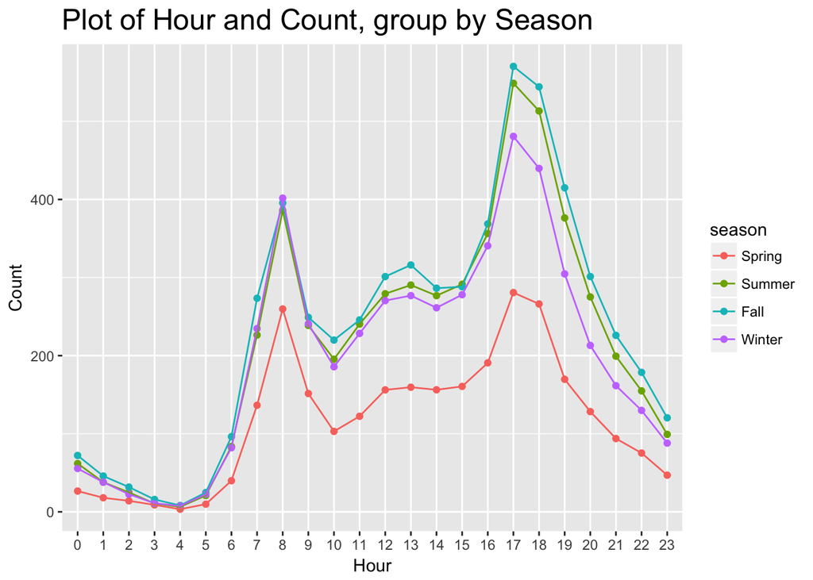

```r
# Calculate the mean of "count", group by "season" and "hour"
season_summary <- train %>% ddply(.(season,hour),
                        summarise, count = mean(count))

# Let's plot!
train %>% ggplot(aes(hour, count, colour = season)) +
  geom_point(data = season_summary, aes(group = season)) +
  geom_line(data = season_summary, aes(group = season)) +
  labs(x = "Hour", y = "Count", title = "Plot of Hour and Count, group by Season") +
  theme(plot.title=element_text(size=18))
```

This plot shows the relationship between `hour` and `count`, group by `season`. We can find, there are two peak hour to rent a bike: 8AM and 17PM, when people normally take commuter. Secondly, people prefer rent a bike in fall and summer than spring.

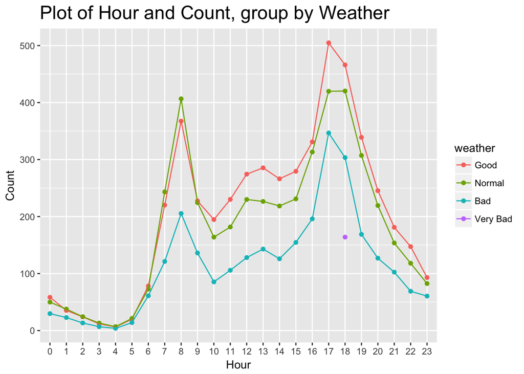

```r
# Same as season, we calculate mean of count
# group by weather and hour variables.
weather_summary <- train %>% ddply(.(weather,hour),
                        summarise, count = mean(count))

# Make a plot group by weather
train %>% ggplot(aes(hour, count, colour = weather)) +
  geom_point(data = weather_summary, aes(group = weather)) +
  geom_line(data = weather_summary, aes(group = weather)) +
  labs(x = "Hour", y = "Count", title = "Plot of Hour and Count, group by Weather") +
  theme(plot.title=element_text(size=18))
```

This plot shows the relationship between `hour` and `count`, group by `weather`. According to the plot, the rental pattern of `hour` is same as the previous one: most of people might use sharing bikes in 8AM and 17PM. When considering weather, people rent more bikes when weather is good or normal than weather is bad. We don’t have many records in very bad weather days, indicating people may not rent bikes in such extreme weather.

### Modeling

#### Random Forest

```r
# Train random forest model by using trainFea dataset
rf <- randomForest(trainFea, train$count, ntree=100, importance=TRUE)

# Predict and summary random forest model
yhat_rf <- predict(rf, newdata = testFea)
defaultSummary(data.frame(obs = test$count,
                          pred = yhat_rf))
```

```
##       RMSE   Rsquared        MAE
## 72.4407038  0.8352909 48.7264828
```

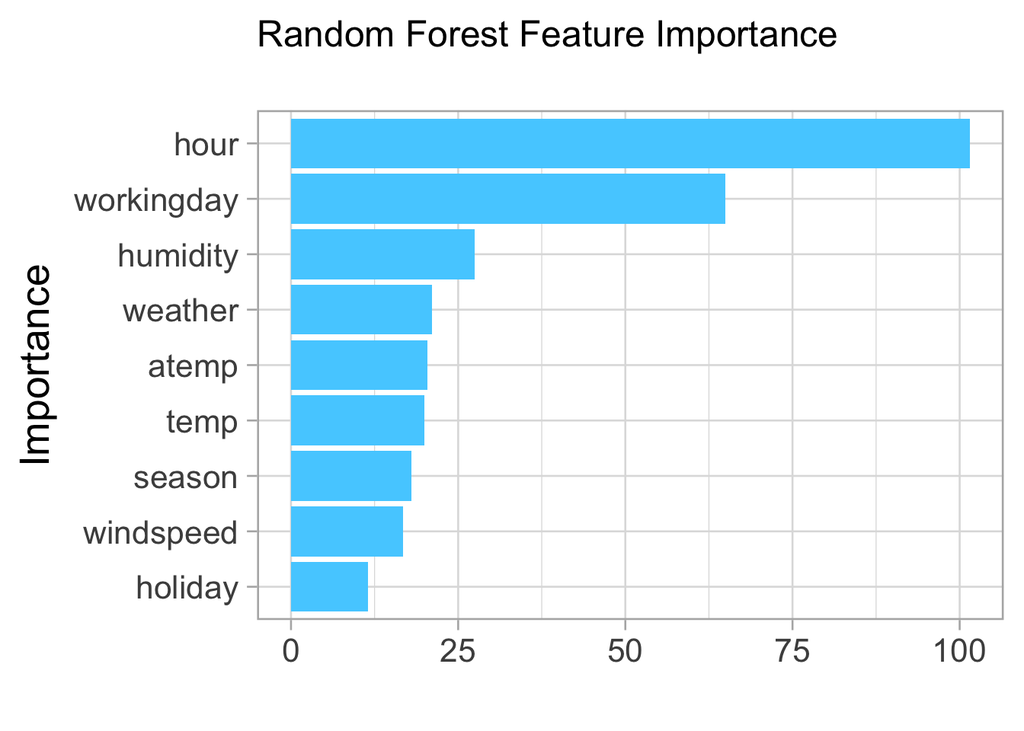

```r
# Variable importance
imp <- importance(rf, type=1)
# Plot variable importance
featureImportance <- data.frame(Feature=row.names(imp), Importance=imp[,1])
p <- ggplot(featureImportance, aes(x=reorder(Feature, Importance), y=Importance)) +
     geom_bar(stat="identity", fill="#53cfff") +
     coord_flip() +
     theme_light(base_size=20) +
     xlab("Importance") +
     ylab("") +
     ggtitle("Random Forest Feature Importance\n") +
     theme(plot.title=element_text(size=18))
p
```

In random forest model, we find `hour` and `workingday` have higher importance, comparing with other variables. It is same with our previous plots that `hour` affects `count` a lot.

### Linear Regression

We also train a linear regression model to predict.

```r
fit_lm <- lm(count ~ ., data = train_eng)
yhat_lm <- predict(fit_lm, newdata = test_eng)
defaultSummary(data.frame(obs = test_eng$count,
                          pred = yhat_lm))
```

```
##       RMSE   Rsquared        MAE
## 98.8691675  0.6874446 74.1304398
```

```r
summary(fit_lm)
```

```
##
## Call:
## lm(formula = count ~ ., data = train_eng)
##
## Residuals:
##     Min      1Q  Median      3Q     Max
## -371.80  -61.23   -7.24   49.40  454.88
##
## Coefficients: (1 not defined because of singularities)
##               Estimate Std. Error t value Pr(>|t|)
## (Intercept) -101.88737    9.32410 -10.927  < 2e-16 ***
## season2       49.33641    4.19656  11.756  < 2e-16 ***
## season3       36.97926    5.38752   6.864 7.19e-12 ***
## season4       66.82416    3.47143  19.250  < 2e-16 ***
## holiday1      -0.63454    7.31619  -0.087 0.930888
## workingday1   11.27778    4.33052   2.604 0.009224 **
## weather2     -11.86853    2.78239  -4.266 2.02e-05 ***
## weather3     -67.58962    4.70331 -14.371  < 2e-16 ***
## weather4    -196.64007  102.00783  -1.928 0.053928 .
## temp           1.87320    0.95477   1.962 0.049803 *
## atemp          3.24320    0.84145   3.854 0.000117 ***
## humidity      -0.59368    0.07986  -7.434 1.16e-13 ***
## windspeed     -0.34721    0.15233  -2.279 0.022670 *
## hour01       -11.84000    7.88150  -1.502 0.133071
## hour02       -28.42807    7.77322  -3.657 0.000257 ***
## hour03       -42.80345    7.90900  -5.412 6.41e-08 ***
## hour04       -38.13668    7.83165  -4.870 1.14e-06 ***
## hour05       -22.34764    7.88784  -2.833 0.004620 **
## hour06        40.08117    7.83519   5.116 3.20e-07 ***
## hour07       173.86628    7.77449  22.364  < 2e-16 ***
## hour08       316.56729    7.84207  40.368  < 2e-16 ***
## hour09       167.68382    7.84224  21.382  < 2e-16 ***
## hour10       112.45061    7.92973  14.181  < 2e-16 ***
## hour11       139.63496    7.98710  17.483  < 2e-16 ***
## hour12       175.98899    7.87283  22.354  < 2e-16 ***
## hour13       181.00585    7.94205  22.791  < 2e-16 ***
## hour14       162.58565    7.99391  20.339  < 2e-16 ***
## hour15       173.48578    8.05261  21.544  < 2e-16 ***
## hour16       233.46370    8.03799  29.045  < 2e-16 ***
## hour17       393.16420    7.95324  49.434  < 2e-16 ***
## hour18       362.17306    7.98261  45.370  < 2e-16 ***
## hour19       246.58769    7.90811  31.182  < 2e-16 ***
## hour20       165.08864    7.83354  21.075  < 2e-16 ***
## hour21       109.99715    7.82565  14.056  < 2e-16 ***
## hour22        76.14872    7.78120   9.786  < 2e-16 ***
## hour23        37.15176    7.76645   4.784 1.75e-06 ***
## weekday2       0.33707    4.34698   0.078 0.938195
## weekday3       4.17806    4.33116   0.965 0.334748
## weekday4       6.34745    4.34444   1.461 0.144040
## weekday5      10.75897    4.32703   2.486 0.012922 *
## weekday6      25.11227    4.20202   5.976 2.38e-09 ***
## weekday7            NA         NA      NA       NA
## year2012      89.99864    2.28642  39.362  < 2e-16 ***
## ---
## Signif. codes:  0 '***' 0.001 '**' 0.01 '*' 0.05 '.' 0.1 ' ' 1
##
## Residual standard error: 101.7 on 8124 degrees of freedom
## Multiple R-squared:  0.6913, Adjusted R-squared:  0.6898
## F-statistic: 443.8 on 41 and 8124 DF,  p-value: < 2.2e-16
```

According to the coefficients, `hour` affects `count` significantly.

#### Lasso Regression

Except for linear regression, we also train a lasso regression to make predictions. Comparing to linear regression, $R^2$ of the training model is going down by using Elastic net.

```r
enetGrid <- expand.grid(.lambda = seq(.05, 1, length = 10),
                        .fraction = seq(.05, 1, length = 10))
ctrl <- trainControl(method = "cv", number = 10)
lasso <- train(count ~ ., data = train_eng, method = "enet",
               trControl = ctrl, tuneGrid = enetGrid)
yhat_las <- predict(lasso, newdata = test_eng)
defaultSummary(data.frame(obs = test_eng$count,
                          pred = yhat_las))
```

```
##       RMSE   Rsquared        MAE
## 99.6334575  0.6825415 75.0040641
```

### Model Summary

[figure not shown]

According to the result table, random forest achieved the lowest RMSE and MAE scores (72.4 and 48.7) and highest $R^2$ score (0.835). It performs in a very good way. The evaluation of linear regressoin and lasso regression are at the same level while linear regression performs slightly well than lasso regression in RMSE, MAE and $R^2$ scores.

## Conclusion

Bike sharing systems have grown rapidly in United States and have provided an innovative transportation option. Washington D.C. is a very special city, where rail network and public transportation is most congested. Launching bike sharing systems here is able to provide a quciker, cheaper and more convenient transportation way for both residents and visitors.

In this project, we are concentrating on how to predict the demand of sharing bike in Washington D.C.. We did features engineering to transform specific variables into right formats and picked up some variables. Then, we drew data visualizations to plot the relationship between `hour`, `season`, `weather` and `count` variables. The plots shows that `hour` affects `count` in both `season` and `weather` groups. It is consistent with what we found in models.

In data modeling process, we implemented three models: random forest, linear regression and lasso regression. Random forest model achieved highest scores among three models. The results of three models show that some particular variables, such as `hour`, significantly affects the prediction of demand.

It is not surprising that daily hours affect demand of bikes. People prefer a cheaper and quciker way to avoid traffic congestion in rush hour, and sharing bikes meet their requirments. Back to the bike imbalancing issues, increasing bike supply in rush hour periods and adjusting seasonally might be a proper way to solve the problem.